# Retail Sector Forcasting

The data used for this project have been taken from the Australian Bureau of Statistics. One is on retail turnover for industries and the other one is on demographic statistics.

## Business Task

You are a data scientist working for an Australian retail chain operating in the clothing a retailing industry.

To date the company has only been running operations in New South Wales which is a state in Australia.

However the board of directors is considering an expansion into one of the following three states: * Queensland * Victoria * Western Australia

You have been asked to assess the business environments for the industry in question in each of these three states and present your findings to the board of directors in person. ### Libraries

```r
library(tidyverse)
library(caTools)
library(readxl)
library(scales)
```

### uploading files

```r
competitors <- read.csv("Competitor-Research.csv")
demographics <- read_xlsx("Australian-Demographic-Statistics.xlsx")
turnover <- read_xlsx("Retail-Turnover-State-by-Industry-Subgroup2.xlsx")
```

### view competitors table

```r
head(competitors)
```

```
##        Company   QLD    WA   VIC   NSW
## 1 Competitor 1 4.57% 4.18% 7.90% 8.54%
## 2 Competitor 2 2.60% 1.88% 8.99% 9.23%
## 3 Competitor 3 2.26% 7.48% 6.71% 7.84%
## 4 Competitor 4 6.47% 6.70% 7.94% 9.89%
## 5 Competitor 5 6.82% 1.17% 8.54% 5.67%
## 6 Competitor 6 4.68% 6.44% 6.52% 3.03%
```

### pivot competitors table to a more machine friendly format

```r
competitorl <- pivot_longer(competitors,cols = c(QLD, WA, VIC, NSW), names_to = "state", values_to = "net_profit_margins")
head(competitorl)
```

```
## # A tibble: 6 x 3
##   Company      state net_profit_margins
##   <chr>        <chr> <chr>
## 1 Competitor 1 QLD   4.57%
## 2 Competitor 1 WA    4.18%
## 3 Competitor 1 VIC   7.90%
## 4 Competitor 1 NSW   8.54%
## 5 Competitor 2 QLD   2.60%
## 6 Competitor 2 WA    1.88%
```

### remove unwanted characters and transform character to numeric type

```r
competitorl$net_profit_margins <- str_remove(competitorl$net_profit_margins,"[%]")

competitorl$net_profit_margins <- as.numeric(competitorl$net_profit_margins)

head(competitorl)
```

```
## # A tibble: 6 x 3
##   Company      state net_profit_margins
##   <chr>        <chr>              <dbl>
## 1 Competitor 1 QLD                 4.57
## 2 Competitor 1 WA                  4.18
## 3 Competitor 1 VIC                 7.9
## 4 Competitor 1 NSW                 8.54
## 5 Competitor 2 QLD                 2.6
## 6 Competitor 2 WA                  1.88
```

### Create Boxplot to have better insights our competitors and determined states with best potential

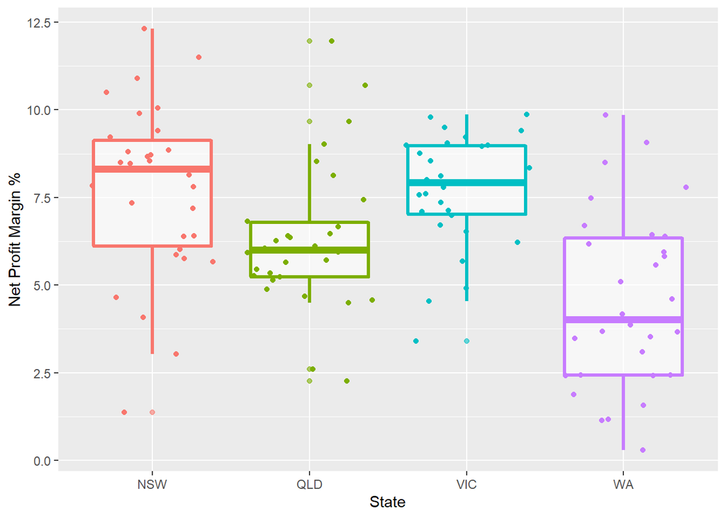

```r
boxplot <- ggplot(competitorl, aes(x = state, y = net_profit_margins, color = state)) +
  geom_boxplot(size=1.2, alpha=.6) +
  geom_jitter() +
  xlab("State") + ylab("Net Profit Margin %") +
  theme(legend.position = "none")

boxplot
```

### Filter retail turnover data to show only data starting from 2000

```r
turnover <- turnover %>%
  filter(Date>= as.Date("2000-01-01"))

head(turnover)
```

[output not shown]

[output cut: 55 more lines]

[output not shown]

### pivot turnover table to a more machine friendly format

```r
turnover <- pivot_longer(turnover, cols = starts_with("Turnover"), values_to = "turnover_$m")
```

### Seperate columns

```r
turnover <- separate(turnover, name, into = c('Turnover','State','Industry'), sep = ';')
turnover <- subset(turnover, select = -c(Turnover))

head(turnover)
```

```
## # A tibble: 6 x 4
##   Date                State       Industry                         `turnover_$m`
##   <dttm>              <chr>       <chr>                                    <dbl>
## 1 2000-01-01 00:00:00 "  New Sou~ "  Supermarket and grocery stor~        1130.
## 2 2000-01-01 00:00:00 "  New Sou~ "  Liquor retailing "                     96.8
## 3 2000-01-01 00:00:00 "  New Sou~ "  Other specialised food retai~         186.
## 4 2000-01-01 00:00:00 "  New Sou~ "  Food retailing "                     1413.
## 5 2000-01-01 00:00:00 "  New Sou~ "  Furniture, floor coverings, ~         176.
## 6 2000-01-01 00:00:00 "  New Sou~ "  Electrical and electronic go~         217.
```

### Filter to see clothing retail industry only

```r
turnoverfinal <- turnover %>%
  filter(Industry == " Clothing retailing ")
head(turnoverfinal)
```

```
## # A tibble: 0 x 4
## # ... with 4 variables: Date <dttm>, State <chr>, Industry <chr>,
## #   turnover_$m <dbl>
```

As you can see 0 rows are returned, couldn’t find source of the problem so my workaround was to filter the data in Excel

```r
# write.csv(turnover, file = "C:\\Users\\username\\Documents\\folderr\\turnover.csv")
```

In Excel after I filtered the data to only show the four states of interest in the clothing retailing industry I uploaded the file

```r
turnover <- read_xlsx("turnover.xlsx")

head(turnover)
```

```
## # A tibble: 6 x 4
##   Date                State           Industry           `Turnover $M`
##   <dttm>              <chr>           <chr>                      <dbl>
## 1 2000-01-01 00:00:00 New South Wales Clothing retailing          213.
## 2 2000-02-01 00:00:00 New South Wales Clothing retailing          173.
## 3 2000-03-01 00:00:00 New South Wales Clothing retailing          215.
## 4 2000-04-01 00:00:00 New South Wales Clothing retailing          218.
## 5 2000-05-01 00:00:00 New South Wales Clothing retailing          242.
## 6 2000-06-01 00:00:00 New South Wales Clothing retailing          269
```

### Plot industry trend over the years

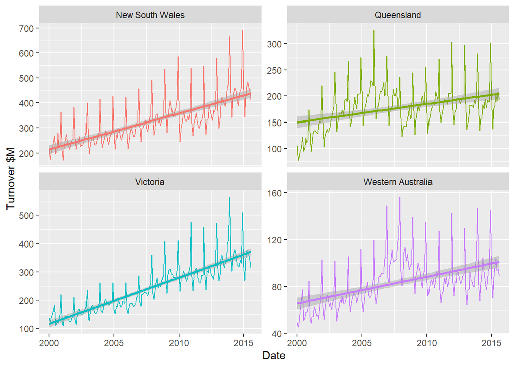

```r
Historicaltrend <- ggplot(turnover, aes(x=Date, y= `Turnover $M`, color= State))+
  geom_line()+
  facet_wrap(~State, scales="free_y")+
  theme(legend.position = "none")+
  geom_smooth(method = 'lm')

Historicaltrend
```

Right now we can’t really compare the industry trends between the states because they have a different number of people. People from different states might be consuming at different rates and population are growing at different rates. We normalized them by dividing every data point by the associated population. This way we know how the per capita consumption is changing in each state and identify in which state this industry is growing the fastest.

## Cleaning up demographics table

```r
head(demographics)
```

```
## # A tibble: 6 x 28
##   Date                `Estimated Residen~ `Estimated Residen~ `Estimated Reside~
##   <dttm>                            <dbl>               <dbl>              <dbl>
## 1 1981-06-01 00:00:00             2608351             1958717            1178447
## 2 1981-09-01 00:00:00             2616060             1964139            1189946
## 3 1981-12-01 00:00:00             2624579             1969349            1200504
## 4 1982-03-01 00:00:00             2634534             1975617            1210128
## 5 1982-06-01 00:00:00             2643527             1981619            1219369
## 6 1982-09-01 00:00:00             2649615             1986589            1228791
## # ... with 24 more variables:
## #   Estimated Resident Population ;  Male ;  South Australia ; <dbl>,
## #   Estimated Resident Population ;  Male ;  Western Australia ; <dbl>,
## #   Estimated Resident Population ;  Male ;  Tasmania ; <dbl>,
## #   Estimated Resident Population ;  Male ;  Northern Territory ; <dbl>,
## #   Estimated Resident Population ;  Male ;  Australian Capital Territory ; <dbl>,
## #   Estimated Resident Population ;  Male ;  Australia ; <dbl>,
## #   Estimated Resident Population ;  Female ;  New South Wales ; <dbl>,
## #   Estimated Resident Population ;  Female ;  Victoria ; <dbl>,
## #   Estimated Resident Population ;  Female ;  Queensland ; <dbl>,
## #   Estimated Resident Population ;  Female ;  South Australia ; <dbl>,
## #   Estimated Resident Population ;  Female ;  Western Australia ; <dbl>,
## #   Estimated Resident Population ;  Female ;  Tasmania ; <dbl>,
## #   Estimated Resident Population ;  Female ;  Northern Territory ; <dbl>,
## #   Estimated Resident Population ;  Female ;  Australian Capital Territory ; <dbl>,
## #   Estimated Resident Population ;  Female ;  Australia ; <dbl>,
## #   Estimated Resident Population ;  Persons ;  New South Wales ; <dbl>,
## #   Estimated Resident Population ;  Persons ;  Victoria ; <dbl>,
## #   Estimated Resident Population ;  Persons ;  Queensland ; <dbl>,
## #   Estimated Resident Population ;  Persons ;  South Australia ; <dbl>,
## #   Estimated Resident Population ;  Persons ;  Western Australia ; <dbl>,
## #   Estimated Resident Population ;  Persons ;  Tasmania ; <dbl>,
## #   Estimated Resident Population ;  Persons ;  Northern Territory ; <dbl>,
## #   Estimated Resident Population ;  Persons ;  Australian Capital Territory ; <dbl>,
## #   Estimated Resident Population ;  Persons ;  Australia ; <dbl>
```

```r
#Filter to only show data starting from the year 2000
demographics <- demographics %>%
  filter(Date >= as.Date('2000-01-01'))
```

```r
demographics1 <- pivot_longer(demographics, cols = starts_with("Estimate"), names_to = "State", values_to = "Population")

head(demographics1)
```

```
## # A tibble: 6 x 3
##   Date                State                                           Population
##   <dttm>              <chr>                                                <dbl>
## 1 2000-03-01 00:00:00 Estimated Resident Population ;  Male ;  New S~    3191864
## 2 2000-03-01 00:00:00 Estimated Resident Population ;  Male ;  Victo~    2313086
## 3 2000-03-01 00:00:00 Estimated Resident Population ;  Male ;  Queen~    1743975
## 4 2000-03-01 00:00:00 Estimated Resident Population ;  Male ;  South~     739568
## 5 2000-03-01 00:00:00 Estimated Resident Population ;  Male ;  Weste~     939331
## 6 2000-03-01 00:00:00 Estimated Resident Population ;  Male ;  Tasma~     233322
```

### Seperate columns

```r
demographics1 <- separate(demographics1, State, into = c('Estimate','Gender','State'), sep = ';')
demographics1 <- subset(demographics1, select = -c(Estimate))

head(demographics1)
```

```
## # A tibble: 6 x 4
##   Date                Gender    State                  Population
##   <dttm>              <chr>     <chr>                       <dbl>
## 1 2000-03-01 00:00:00 "  Male " "  New South Wales "      3191864
## 2 2000-03-01 00:00:00 "  Male " "  Victoria "             2313086
## 3 2000-03-01 00:00:00 "  Male " "  Queensland "           1743975
## 4 2000-03-01 00:00:00 "  Male " "  South Australia "       739568
## 5 2000-03-01 00:00:00 "  Male " "  Western Australia "     939331
## 6 2000-03-01 00:00:00 "  Male " "  Tasmania "              233322
```

### filter to only show population only for the four states of interest

```r
demographics2 <- demographics1 %>%
  filter( State == c('Victoria', 'New South Wales', 'Queensland','South Australia'))
head(demographics2)
```

```
## # A tibble: 0 x 4
## # ... with 4 variables: Date <dttm>, Gender <chr>, State <chr>,
## #   Population <dbl>
```

As you can see 0 rows are returned just like last time, again my workaround was to filter the data in Excel

```r
# write.csv(demographics1, file = "C:\\Users\\username\\Documents\\folderr\\demographics.csv")
```

In Excel after I filtered the data to only show the four states of interest in the clothing retailing industry I uploaded the file

```r
demographics <- read_xlsx("demographics.xlsx")
```

### Join turnover and demographics dataframes

```r
mergedt <- inner_join(turnover,demographics, by = NULL, copy = FALSE)
```

Want to look at population as a whole so we filter out population for male and female

```r
mergedt <- mergedt%>%
  filter(Gender == 'Persons')
```

To get sales per capita we devide turnover by population

```r
mergedt$Sales_per_capita <- (mergedt$`Turnover $M`/mergedt$Population)*1000000
```

Plot industry trend

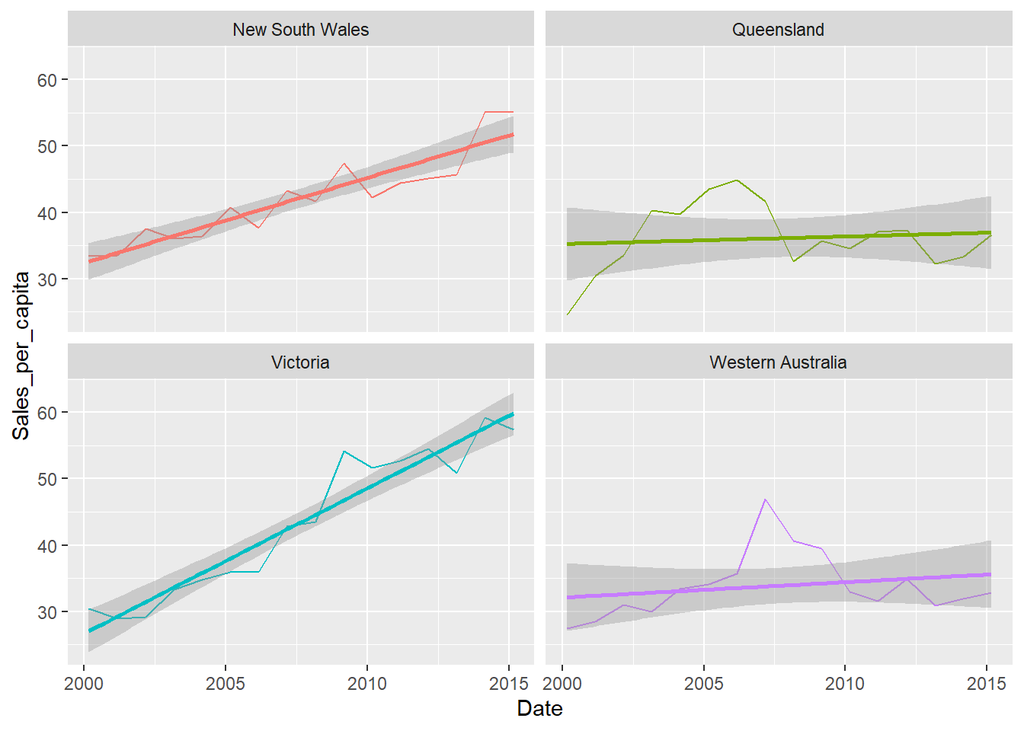

```r
ggplot(mergedt, aes(x=Date, y= Sales_per_capita, color= State))+
  geom_line()+
  facet_wrap(~State)+
  theme(legend.position = "none")+
  geom_smooth(method = 'lm')
```